# Path analysis

qingye

2017-05-19

数据来源的时间是:2017年5月14日 有潜在购买需求的用户有88人 如何定义有潜在购买需求：当天访问过以下页面：

[1] “设计师预约提交(设计师订单确认)”  
[2]“购物车”  
[3] “支付页”  
[4]“订单确认页（支付购买）”  
[5] “订单详情页”

```r
library(data.table)
library(D3partitionR)
library(readr)
library(readxl)
tb_3 = data.table(read_xlsx('~/data/tb3.xlsx'))
tb_4 = tb_3[sumvalue<=30,]
tb_5 = tb_3[sumvalue>30,]
# D3partitionR(data=list(path=tb_4$page_name,value=1),type = 'sunburst')
```

上面是部分代码

[interactive chart not shown]

以上是购买用户路径图 从路径图可以看到，有潜在购买欲的用户的行为比较多元化，比较复杂 很多有购买倾向的用户会在案例列表，案例详情页面来回徘徊数十次 还有部分用户则非常直接，进入订单确认页，应该是已经得到足够的情报，使用APP来下单

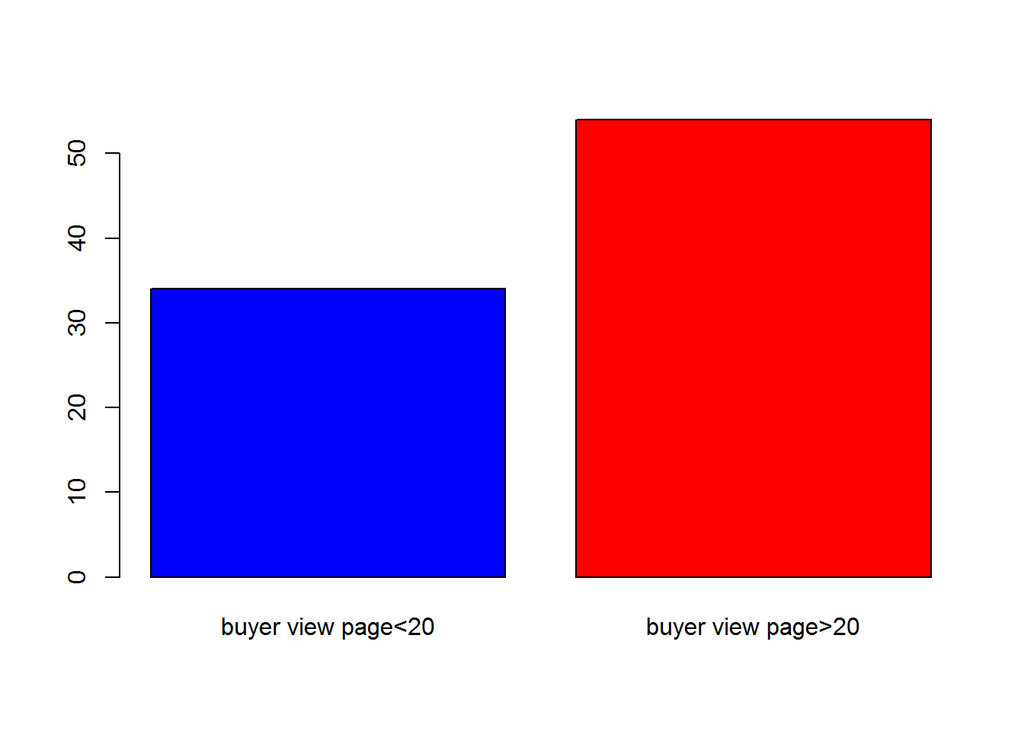

这显示了对于购买用户而言 访问的页面数比较多，大部分都多于20页

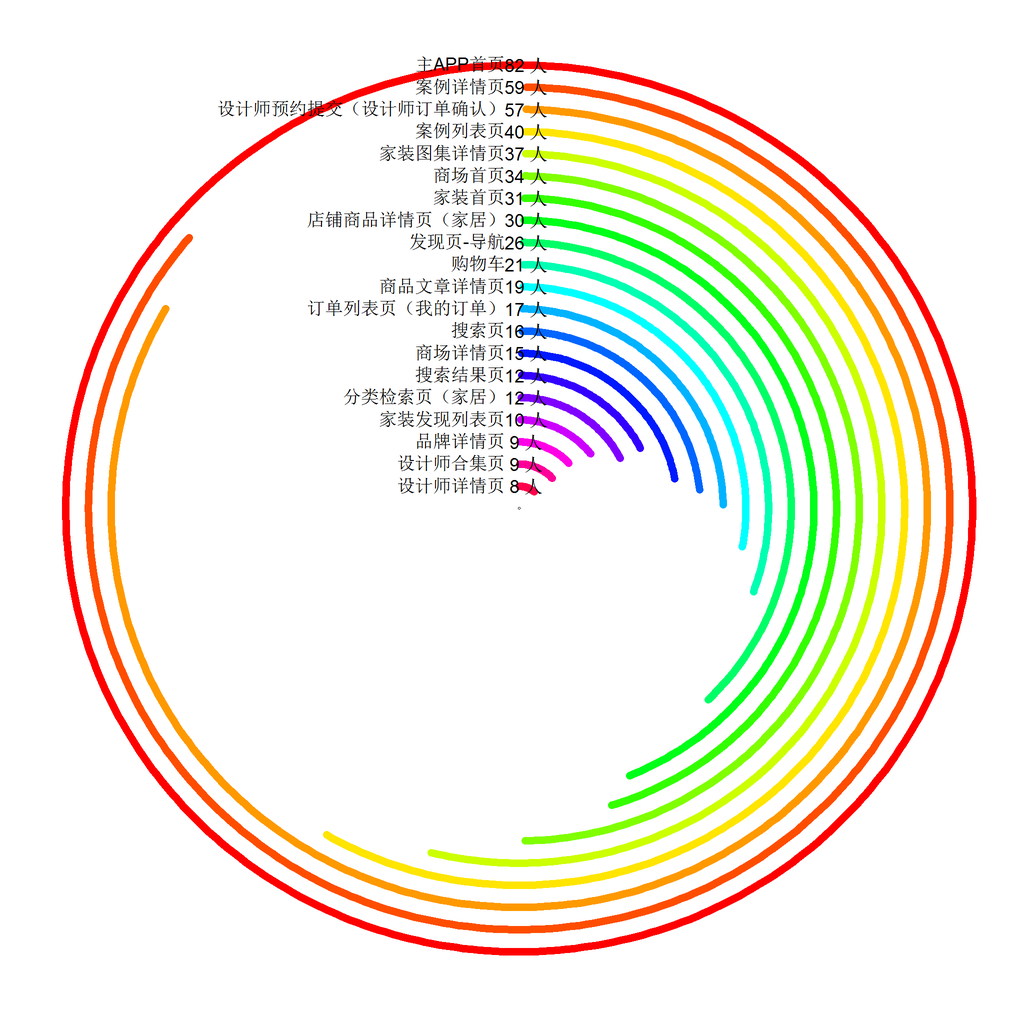

一共有88个用户，可以看出，除了各大首页以及购物车订单页外，家装图集详情页以及案例列表，案例详情，商场详情，搜索，搜索结果等会被潜在购买者经常关注

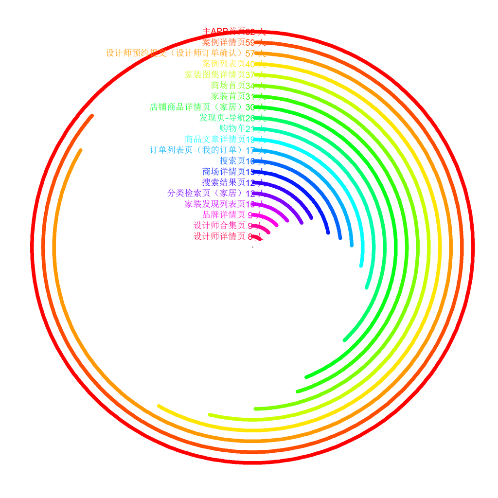